[figure not shown]

# Grado de Ciencia de Datos.

## Práctica 3. SVM para clasificación

#### Yolanda Vives Gilabert, Álvaro Moreno Martínez, Marcelino Martínez Sober

Andreu Cantó y Amparo Gálvez

#### Objetivo

El objetivo de esta práctica es ilustrar cómo se pueden ajustar los hiperparámetros de un clasificador, como la **SVM**, en un problema de clasificación binario, y posteriormente se mostrará como puede generalizarse a un problema multiclase.

En este enlace hay una explicación sencilla sobre la SVM https://www.cienciadedatos.net/documentos/34_maquinas_de_vector_soporte_support_vector_machines

```python
# Autorecarga de paquetes
%load_ext autoreload
%autoreload 2
# Gráficos insertados en documento
%matplotlib inline
```

```python
import numpy as np
import matplotlib.pyplot as plt
import scipy
from sklearn.svm import SVC # support vector classifier
from sklearn.datasets import make_moons, load_iris
from sklearn.model_selection import train_test_split, KFold, GridSearchCV
from sklearn.decomposition import PCA
```

#### Usaremos un ejemplo "juguete" para ilustrar cómo funciona la SVM y cómo influyen los hiperparámetros

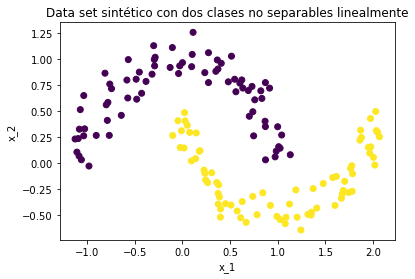

```python
# Generamos los datos, los representamos
X, y = make_moons(n_samples=150, noise=0.1) # incluir random_state para repetitividad

fig,ax = plt.subplots()
ax.scatter(X[:,0], X[:,1], c=y)
ax.set_xlabel('x_1')
ax.set_ylabel('x_2')
ax.set_title('Data set sintético con dos clases no separables linealmente')

# Dividimos ya desde el principio nuestros datos en entrenamiento y test
Xtrain, Xtest, ytrain, ytest = train_test_split(X, y, test_size=1/3)
```

#### Normalización de los datos

El algoritmo de entrenamiento de las SVM es bastante sensible al rango de los datos, pudiendo dar problemas de estabilidad en caso de que los datos de entrada (las $X$) no estén debidamente normalizados.

Para evitar dichos problemas y mejorar los resultados el primer paso que debemos realizar al trabajar con SVMs es normalizar los datos. Las normalizaciones que mejores resultados proporcionan se obtienen al escalar los datos entre 0 y 1 (o entre -1 y 1), o normalizarlos restando la media y dividiendo por la desviación estándar (estandarización).

Para más información sobre la SVM en general y sobre este tema de escalado en particular debéis leer este documento: https://www.csie.ntu.edu.tw/~cjlin/papers/guide/guide.pdf.

#### En primer lugar vamos a mostrar cómo cambia la frontera de separación no lineal al variar la escala del kernel

Un *kernel* es una transformación que mapea los datos originales en un nuevo espacio de alta dimensión que ofrece unas características especiales para la resolución de un determinado problema.

Usaremos el kernel RBF (Radial Basis Function) que es probablemente el más utilizado para resolver problemas de clasificación no lineales. Su definición es $$ k(x_1,x_2) = \exp\left(\frac{\|x_1-x_2\|^2}{2\sigma^2}\right) $$ donde $\sigma^2$ define la anchura (o escala) de esta función.

Este hiperparámetro $\sigma^2$ es clave para determinar el comportamiento de la SVM en problemas no lineales, puesto que es el que determina el espacio de alta dimensión al que implícitamente mapeamos las muestras del espacio original, $x$, al espacio de caraterísticas mediante una función $\varphi$ cuya expresión explícita es, en principio, desconocida.

En la implementación de scikit-learn el kernel RBF se define por $k(x_1,x_2) = \exp(\gamma\|x_1-x_2\|^2)$, sustituyendo el parámetro $\sigma$ por otro relacionado por la expresión $\gamma=\frac{1}{2\sigma^2}$.

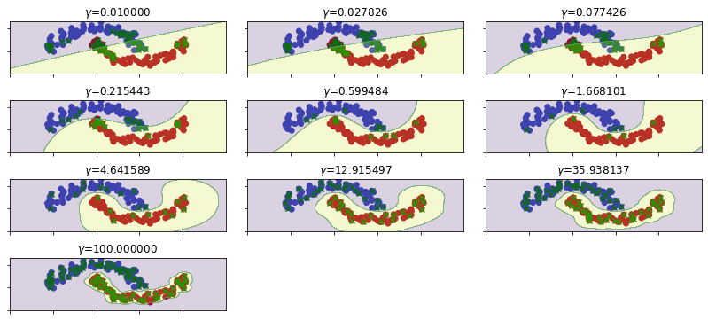

```python
h = 0.01
xrange = np.arange(-2, 3, h)
yrange = np.arange(-1, 1.3, h)

#np.meshgrid genera un array de coordenadas para evaluar superficies de nivel
xx, yy = np.meshgrid(xrange, yrange)


#np.c_ dispone en columnas dos arrays unidimensionales
#.ravel dispone un array NxM en un array unidiomensional de tamaño 1xN*M
zz = np.c_[xx.ravel(), yy.ravel()]

plt.figure(figsize=(14,6))
C = 10
#np.logspace genera un array de 10 muestras entre 10**-2 y 10**2 distribuidas logaritmicamente
gammas = np.logspace(-2, 2, 10)

for n, gamma in enumerate(gammas):
    #SVC Función que define la SVM en scikitlearn
    svc = SVC(kernel='rbf', gamma=gamma, C=C)
    #Entrenamos la svm con datos de train
    svc.fit(Xtrain, ytrain)
    Z = svc.predict(zz)
    Z = Z.reshape(xx.shape)
    # Draw
    ax = plt.subplot(4, 3, n+1)
    #Pintamos el dataset, con el color como la clase Azul=1 Rojo=0
    plt.scatter(X[:,0], X[:,1], c=y, cmap=plt.cm.coolwarm)
    #Pintamos los vectores soporte como cruces verdes empleando el atributio support_vectors_
    plt.scatter(svc.support_vectors_[:,0], svc.support_vectors_[:,1],\
                c='g', marker='x')

    #Pintamos la frontera de separación, en función de Gamma,  sigma
    plt.contourf(xx, yy, Z, alpha=0.2)
    plt.title(r'$\gamma$=%f' % gamma)
    plt.setp(ax, xticklabels=[], yticklabels=[])
plt.subplots_adjust(wspace=0.1, hspace=0.5)
```

**Ejercicio** Repite el apartado anterior fijando $\gamma=5$ y variando C. Para *C* usa 12 valores con espaciado logarítmico entre 0.01 y 1000

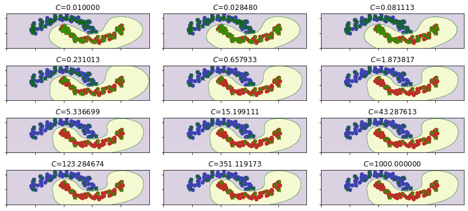

```python
h = 0.01
xrange = np.arange(-2, 3, h)
yrange = np.arange(-1, 1.3, h)

#np.meshgrid genera un array de coordenadas para evaluar superficies de nivel
xx, yy = np.meshgrid(xrange, yrange)


#np.c_ dispone en columnas dos arrays unidimensionales
#.ravel dispone un array NxM en un array unidiomensional de tamaño 1xN*M
zz = np.c_[xx.ravel(), yy.ravel()]

plt.figure(figsize=(14,6))
gamma = 5
#np.logspace genera un array de 10 muestras entre 10**-2 y 10**2 distribuidas logaritmicamente
Cs = np.logspace(-2, 3, 12)

for n, C in enumerate(Cs):
    #SVC Función que define la SVM en scikitlearn
    svc = SVC(kernel='rbf', gamma=gamma, C=C)
    #Entrenamos la svm con datos de train
    svc.fit(Xtrain, ytrain)
    Z = svc.predict(zz)
    Z = Z.reshape(xx.shape)
    # Draw
    ax = plt.subplot(4, 3, n+1)
    #Pintamos el dataset, con el color como la clase Azul=1 Rojo=0
    plt.scatter(X[:,0], X[:,1], c=y, cmap=plt.cm.coolwarm)
    #Pintamos los vectores soporte como cruces verdes empleando el atributio support_vectors_
    plt.scatter(svc.support_vectors_[:,0], svc.support_vectors_[:,1],\
                c='g', marker='x')

    plt.contourf(xx, yy, Z, alpha=0.2)
    plt.title(r'$C$=%f' % C)
    plt.setp(ax, xticklabels=[], yticklabels=[])
plt.subplots_adjust(wspace=0.1, hspace=0.5)
```

#### Escogiendo los hiperparámetros óptimos

Como acabamos de ver los parámetros libres de la SVM (también llamados hiperparámetros) son clave para el buen funcionamiento del algoritmo. La pregunta que sigue a continuación es lógicamente ¿cómo averiguamos cuáles son los mejores?

Hay varias formas de atacar el problema pero habitualmente se recurre a hacer un barrido donde probamos varios valores y nos quedamos con la mejor combinación. Aún así, ¿como fijamos el rango de valores a probar?

El parámetro *C* permite ajustar cuánto se penalizan los errores cometidos por el clasificador. Valores bajos de C permiten más errores, valores altos penalizan fuertemente los mismos. Valores demasiado bajos pueden provocar que se penalicen tan poco los errores que el modelo no se entrene correctamene. Por el contrario valores altos penalizan tanto los errores que provocan que el modelo se aprenda "de memoria" los datos, siendo incapaz de generalizar y predecir correctamene sobre datos no vistos (se produce un sobre-entrenamiento, u *overfitting*). En general podemos probar entre valores entre $10^{-3}$ y $10^3$.

#### El "truco" para la escala del kernel RBF

En cuanto a la $\sigma$ del kernel RBF, para saber por dónde empezar, una técnica consiste en estimar la distancia media entre las muestras de entrenamiento. Dado que este kernel mide la distancia (o diferencia) entre muestras, $\|x_1-x_2\|^2$, es lógico utilizar un valor de $\sigma^2$ que esté en el mismo orden de magnitud. A partir de este valor empírico del valor de $\sigma^2$ se puede barrer en un rango de entre $10^{-2}$ ó $10^{-1}$ y $10$ ó $100$ veces este valor. Puedes usa la función *pdist* de *scipy.spatial.distance* para calcular la distancia entre muestras

#### El truco de la sigma

```python
#Estimamos la distancia media en el data set
sigma_mean = np.mean(scipy.spatial.distance.pdist(X))
sigma_min = sigma_mean * 0.1 #Entre 0.01*distancia media
sigma_max = sigma_mean * 10 # 100* diatancia media
```

#### Recordemos que en scikit-learn en lugar de $\sigma$ tenemos $\gamma = \frac{1}{2\sigma^2}$

```python
# Pasamos de sigma a gamma

gamma_min = np.log10(1/2/sigma_max**2)
gamma_max = np.log10(1/2/sigma_min**2)
```

#### Probando las diferentes combinaciones de parámetros

Determinar los rangos de parámetros a probar es el primer paso, pero ahora la cuestión es cómo probarlos adecuadamente.

Recordemos que solo tenemos un conjunto de entrenamiento, en nuestro caso `Xtrain` e `ytrain`, y que no debemos utilizar el conjunto de test para entrenar el modelo ya que este conjunto debe utilizarse únicamente para testear el modelo final.

Una opción podría ser entrenar con todo el conjunto de entrenamiento y validar sobre el mismo, pero haciendo esto corremos un alto riesgo de sobre-entrenar el modelo a los datos de entrenamiento, mermando sus capacidades de generalización.

Para evitar este problema vamos a subdividir de nuevo el conjunto de entrenamiento para disponer de conjuntos de entrenamiento y validación separados para evaluar el rendimiento de cada combinación de hiperparámetros. Podemos usar cualquiera de la técnicas vistas en la práctica anterior, *hold-out*, *k-fold*, etc. Para este ejemplo usaremos *k-fold* con $k=5$.

**Nota importante**: fíjate que en la práctica anterior usábamos las técnicas de división de conjuntos solamente para testear el modelo. En esta práctica vamos a usar *hold-out* para testear el modelo final (igual que en la práctica anterior) y *k-fold* para ajustar los parámetros libres.

**Ejercicio:** completa el siguiente código

Considera 10 valores, con espaciado logarítmico, para definir $\gamma$

```python
# CÓDIGO ALUMNO
# Definimos los  rangos
npoints = 10
gammas = np.logspace(gamma_min, gamma_max, npoints)
Cs = np.logspace(-3,3, 7) #Valores recomendados

# Definimos el k-fold
kfold_splits = 5
kfold = KFold(n_splits=kfold_splits)

# Vamos probando cada combinación en cada subconjunto de entrenamiento y test
accuracies = []
n = 1
for itrain, itest in kfold.split(Xtrain):
    print('kfold %d ...' % n)
    n += 1
    for gamma in gammas:
        for C in Cs:
            # Creamos el modelo
            svc = SVC(kernel='rbf', gamma=gamma, C=C)
            # Completa ---------------------------------------
            # Entrena usando Xtrain, ytrain y los índices itrain
            svc.fit(Xtrain[itrain], ytrain[itrain])

            # Evalúa el resultado (usa score) sobre Xtrain, ytrain y los índices itest
            acc = svc.score(Xtrain[itest], ytrain[itest])
            # ------------------------------------------------
            accuracies.append(acc)
```

```
kfold 1 ...
kfold 2 ...
kfold 3 ...
kfold 4 ...
kfold 5 ...
```

```python
# Buscamos la combinación que nos haya proporcionado el mejor resultado
# en las pruebas

accuracies = np.array(accuracies).reshape((kfold_splits, npoints, 7))
macc = np.mean(accuracies, axis=0)
idx = np.unravel_index(np.argmax(macc), macc.shape)
best_gamma, best_C = gammas[idx[0]], Cs[idx[1]]
print('Best gamma:', best_gamma, 'best C:', best_C, 'Higest accuracy:', macc[idx[0], idx[1]])
```

```
Best gamma: 0.19078496736962636 best C: 100.0 Higest accuracy: 1.0
```

Ahora entrenamos el modelo con los los parámetros óptimos con todo el conjunto de entrenamiento, y representamos las fronteras de separación entre clases.

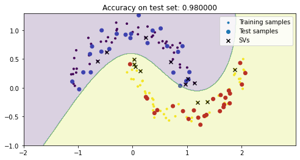

```python
# Train the final model using the best gamma and C combo
svc = SVC(kernel='rbf', gamma=best_gamma, C=best_C)
svc.fit(Xtrain, ytrain)
# Accuracy on test set
acc = svc.score(Xtest, ytest)
# Represent
Z = svc.predict(zz).reshape(xx.shape)
plt.figure(figsize=(8,4))
plt.scatter(Xtrain[:,0], Xtrain[:,1], c=ytrain, marker='.', label='Training samples')
plt.scatter(Xtest[:,0], Xtest[:,1], c=ytest, marker='o', cmap=plt.cm.coolwarm, \
            label='Test samples')
plt.scatter(svc.support_vectors_[:,0], svc.support_vectors_[:,1], c='black', \
            marker='x', label='SVs')
plt.contourf(xx, yy, Z, alpha=0.2)
plt.legend(), plt.title('Accuracy on test set: %f' % acc);
```

#### Problemas de clasificación de más de dos clases

La SVM es por naturaleza un clasificador binario que define el hiperplano (la frontera) que separa dos clases. Para resolver problemas donde tenemos que clasificar más de dos clases se recurre principalmente a dos estrategias:

1. OVR (one-vs-rest), o uno contra el resto. Aquí lo que se hace es entrenar un clasificador para cada clase existente y enfrentarlo contra el resto de clases agrupadas. Para predecir se pasa la muestra a clasificar por cada uno de los modelos entrenados y se le asigna la clase del clasificador con mayor score (probabilidad).
2. OVO (one-vs-one), o uno contra otro. Aquí si tenemos $C$ clases entrenamos $C(C-1)/2$ modelos que deciden entre cada par de clases. Para predecir usamos todos los modelos entrenados y de nuevo se escoge la clase más votada.

En la literatura existen trabajos donde se muestra que no existen diferencias significativas en los resultados obtenidos mediante estas dos estrategias (ver https://www.csie.ntu.edu.tw/~cjlin/papers/multisvm.pdf).

Por defecto las SVM de scikit-learn usan OVR, aunque os aconsejamos leer siempre la documentación porque esto puede cambiar.

**Ejercicio**: enumera las ventajas e incovenientes que crees que tienen las estrategias OVR y OVO.

OVR: Un clasificador por clase, si tenemos c clases tendremos c clasificafores

VENTAJAS:

- EL numero de clsificadores será igual a C
- Más eficiente en términos computacionales, ya que se entrena un clasificador por clase.
- Menos propenso al sobreajuste en comparación con OVO.
- Fácil de implementar y entender.

DESVENTAJAS:

- Puede generar clases desbalanceadas
- La probabilidad de clasificación no siempre es muy precisa.

OVO: un clasificadro para cada par de clases

VENTAJAS

- El coste computacional es grande
- Es mas sencillo
- Eliminamos el problema de desbalance

DESVENTAJAS

- Mayor complejidad
- Requiere más tiempo de entrenamiento, ya que se deben entrenar clasificadores para cada par de clases.
- El tiempo de entrenamiento puede aumentar cuadráticamente con el número de clases, lo que lo hace menos eficiente en conjuntos de datos grandes con muchas clases.

#### Para ilustrar el problema multiclase vamos a trabajar de nuevo con el dataset IRIS y probaremos la estrategia OVO

```python
X, y = load_iris(return_X_y=True)
```

**Ejercicio.** Divide X e y utilizando hold-out (2/3 train, 1/3 test).

```python
Xtrain, Xtest, ytrain, ytest = train_test_split(X, y, test_size=1/3)
```

**Ejercicio.** Reduce la dimensionalidad de las $X$ a solo dos componentes mediante la PCA y visualiza los datos en el espacio de las componentes principales (PC2 vs. PC1), coloreando según la clase.

```python
pca = PCA(n_components=2)

X_train_pca = pca.fit_transform(Xtrain)
X_test_pca = pca.fit_transform(Xtest)
Xt = pca.fit_transform(X)
```

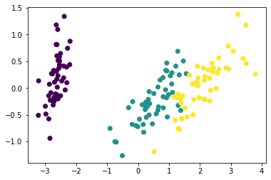

```python
# Visualizamos las clases en el espacio de las componentes principales
plt.scatter(Xt[:,0], Xt[:,1], c=y)
```

#### GridSearchCV

Para entrenar los modelos vamos a recurrir de nuevo al k-fold, pero esta vez utilizaremos la función `GridSearchCV` de scikit-learn para automatizar el proceso.

Esta función toma un modelo de scikit-learn y un conjunto de parámetros y automáticamente realiza el proceso de ajuste de los mismos utilizando un k-fold. Parámetros relevantes:

- El modelo a entrenar.
- El grid de parámetros a utilizar (*param_grid*).
- `cv`: en número $k$ de *folds* a usar. Usaremos 5.
- `verbose`: para que proporcione más o menos información.
- `n_jobs`: número de suprocesos a utilizar para entrenar. Esto disminuye muy significativamente el tiempo de entrenamiento necesario en sistemas con varios procesadores.

```python
# Creamos los tres modelos necesarios para implementar el OVO
sigma_mean = np.mean(scipy.spatial.distance.pdist(Xt))
gamma_mean = 1/2/sigma_mean**2
param_grid = [{
    'C': np.logspace(-3, 3, 7),
    'gamma': np.logspace(np.log10(gamma_mean*0.1), np.log10(gamma_mean*10), 20),
    'kernel': ['rbf']
}]
gcv1 = GridSearchCV(SVC(), param_grid=param_grid, cv=5, verbose=1, n_jobs=2)
gcv2 = GridSearchCV(SVC(), param_grid=param_grid, cv=5, verbose=0, n_jobs=2)
gcv3 = GridSearchCV(SVC(), param_grid=param_grid, cv=5, verbose=0, n_jobs=2)
```

**Ejercicio.** Entrena los clasificadores gcv1, gcv2 y gcv3 para las clases 0 y 1, 0 y 2, y 1 y 2, respectivamente.

```python
# Clases 0 y 1
gcv1.fit(X_train_pca[np.isin(ytrain, [0, 1])], ytrain[np.isin(ytrain, [0, 1])])
```

```
Fitting 5 folds for each of 140 candidates, totalling 700 fits
```

```
GridSearchCV(cv=5, estimator=SVC(), n_jobs=2,
             param_grid=[{'C': array([1.e-03, 1.e-02, 1.e-01, 1.e+00, 1.e+01, 1.e+02, 1.e+03]),
                          'gamma': array([0.00817026, 0.01041116, 0.01326668, 0.0169054 , 0.02154213,
       0.02745059, 0.0349796 , 0.04457363, 0.05679906, 0.07237763,
       0.092229  , 0.11752511, 0.14975931, 0.19083454, 0.24317568,
       0.30987268, 0.39486301, 0.50316405, 0.64116937, 0.81702609]),
                          'kernel': ['rbf']}],
             verbose=1)
```

```python
# Clases 0 y 2
gcv2.fit(X_train_pca[np.isin(ytrain, [0, 2])], ytrain[np.isin(ytrain, [0, 2])])
```

```
GridSearchCV(cv=5, estimator=SVC(), n_jobs=2,
             param_grid=[{'C': array([1.e-03, 1.e-02, 1.e-01, 1.e+00, 1.e+01, 1.e+02, 1.e+03]),
                          'gamma': array([0.00817026, 0.01041116, 0.01326668, 0.0169054 , 0.02154213,
       0.02745059, 0.0349796 , 0.04457363, 0.05679906, 0.07237763,
       0.092229  , 0.11752511, 0.14975931, 0.19083454, 0.24317568,
       0.30987268, 0.39486301, 0.50316405, 0.64116937, 0.81702609]),
                          'kernel': ['rbf']}])
```

```python
# Clases 1 y 2
gcv3.fit(X_train_pca[np.isin(ytrain, [1, 2])], ytrain[np.isin(ytrain, [1, 2])])
```

```
GridSearchCV(cv=5, estimator=SVC(), n_jobs=2,
             param_grid=[{'C': array([1.e-03, 1.e-02, 1.e-01, 1.e+00, 1.e+01, 1.e+02, 1.e+03]),
                          'gamma': array([0.00817026, 0.01041116, 0.01326668, 0.0169054 , 0.02154213,
       0.02745059, 0.0349796 , 0.04457363, 0.05679906, 0.07237763,
       0.092229  , 0.11752511, 0.14975931, 0.19083454, 0.24317568,
       0.30987268, 0.39486301, 0.50316405, 0.64116937, 0.81702609]),
                          'kernel': ['rbf']}])
```

**Ejercicio.** Obtén las predicciones del conjunto de test (`Xtest`) en los tres modelos entrenados

```python
# Predictions
p1 = gcv1.predict(X_test_pca)
p2 = gcv2.predict(X_test_pca)
p3 = gcv3.predict(X_test_pca)
```

**Ejercicio.** Utilizando `scipy.stats.mode` (la moda) obtén la clase más votada

```python
moda = []
for i in range(len(p1)):
    m = scipy.stats.mode([p1[i],p2[i],p3[i]])
    moda.append(m.mode[0])
print(moda)
```

```
[2, 2, 2, 0, 2, 0, 1, 0, 1, 2, 0, 2, 1, 0, 0, 1, 2, 2, 0, 1, 0, 0, 1, 1, 0, 1, 2, 1, 1, 0, 1, 1, 1, 0, 2, 2, 2, 0, 0, 1, 0, 1, 2, 2, 1, 0, 2, 2, 0, 1]
```

#### Comparación con OVO de scikit-learn

Por defecto las SVC de scikit-learn implentan la estrategia OVR.

```python
# SVC already performs OVR (one-vs-rest) or OVO (one-vs-one) for you
param_grid = [{
    'C': np.logspace(-3, 3, 7),
    'gamma': np.logspace(np.log10(gamma_mean*0.1), np.log10(gamma_mean*10), 20),
    'kernel': ['rbf'],
    'decision_function_shape':
    ['ovo']
}]
gcv = GridSearchCV(SVC(), param_grid=param_grid, cv=5, verbose=1, n_jobs=2)
```

**Ejercicio**. Entrena el clasificador y obtén su *score*

```python
gcv.fit(X_train_pca, ytrain)
```

```
Fitting 5 folds for each of 140 candidates, totalling 700 fits
```

```
GridSearchCV(cv=5, estimator=SVC(), n_jobs=2,
             param_grid=[{'C': array([1.e-03, 1.e-02, 1.e-01, 1.e+00, 1.e+01, 1.e+02, 1.e+03]),
                          'decision_function_shape': ['ovo'],
                          'gamma': array([0.00817026, 0.01041116, 0.01326668, 0.0169054 , 0.02154213,
       0.02745059, 0.0349796 , 0.04457363, 0.05679906, 0.07237763,
       0.092229  , 0.11752511, 0.14975931, 0.19083454, 0.24317568,
       0.30987268, 0.39486301, 0.50316405, 0.64116937, 0.81702609]),
                          'kernel': ['rbf']}],
             verbose=1)
```

```python
acc = gcv.score(X_test_pca, ytest)
print('Score: ', acc)
```

```
Score:  0.9
```

**Ejercicio.** Representa las fronteras de separación para el problema multiclase

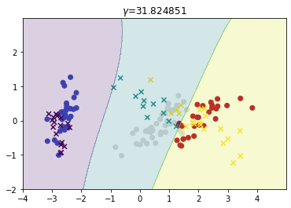

```python
h = 0.01
xrange = np.arange(-4,5,h)
yrange = np.arange(-2,3,h)
xx, yy = np.meshgrid(xrange, yrange)
zz = np.c_[xx.ravel(), yy.ravel()]
Z = gcv.predict(zz)
Z = Z.reshape(xx.shape)
plt.scatter(X_train_pca[:,0], X_train_pca[:,1], c=ytrain, cmap=plt.cm.coolwarm)
plt.scatter(X_test_pca[:,0], X_test_pca[:,1],c=ytest, marker='x')
plt.contourf(xx, yy, Z, alpha=0.2)
plt.title(r'$\gamma$=%f' % gamma)
plt.setp(ax, xticklabels=[], yticklabels=[])
plt.figure(figsize=(12,4))
plt.show()
```

**Ejercicio** Implementa la estrategia OVR para el problema de 3 clases y compara tus resultados con la SVC usando `decision_function_shape='ovr'`. La figura siguiente muestra gráficamente esta estrategia.

[figure not shown]

```python
param_grid = [{
    'C': np.logspace(-3, 3, 7), 'gamma': np.logspace(np.log10(gamma_mean*0.1), np.log10(gamma_mean*10), 20), 'kernel': ['rbf'],
    'decision_function_shape': ['ovr']
}]
gcv2 = GridSearchCV(SVC(), param_grid=param_grid, cv=5, verbose=1, n_jobs=2)
```

```python
gcv2.fit(X_train_pca, ytrain)
```

```
Fitting 5 folds for each of 140 candidates, totalling 700 fits
```

```
GridSearchCV(cv=5, estimator=SVC(), n_jobs=2,
             param_grid=[{'C': array([1.e-03, 1.e-02, 1.e-01, 1.e+00, 1.e+01, 1.e+02, 1.e+03]),
                          'decision_function_shape': ['ovr'],
                          'gamma': array([0.00817026, 0.01041116, 0.01326668, 0.0169054 , 0.02154213,
       0.02745059, 0.0349796 , 0.04457363, 0.05679906, 0.07237763,
       0.092229  , 0.11752511, 0.14975931, 0.19083454, 0.24317568,
       0.30987268, 0.39486301, 0.50316405, 0.64116937, 0.81702609]),
                          'kernel': ['rbf']}],
             verbose=1)
```

```python
gcv2.score(X_test_pca, ytest)
```

```
0.9
```

**Extra points !!**

Una vez determinados los parámetros óptimos para la svm en clasificación vuelve a hacer un nuevo barrido más fino usando como límites los del tramo correspondiente a los extremos de los intervalos que contienen la mejor combinación de parámetros.